> **Tip**: Welcome to the Investigate a Dataset project! You will find tips in quoted sections like this to help organize your approach to your investigation. Before submitting your project, it will be a good idea to go back through your report and remove these sections to make the presentation of your work as tidy as possible. First things first, you might want to double-click this Markdown cell and change the title so that it reflects your dataset and investigation.

# Project: Investigate TMDB Dataset

- Introduction
- Data Wrangling
- Exploratory Data Analysis
- Conclusions

## Introduction

The TMDB dataset contains the data about 10866 movies collected from The Movie Database. This data contains following information about each movie- 'id', 'imdb_id', 'popularity', 'budget', 'revenue', 'original_title','cast', 'homepage', 'director', 'tagline', 'keywords', 'overview','runtime', 'genres', 'production_companies', 'release_date','vote_count', 'vote_average', 'release_year', 'budget_adj','revenue_adj'.

It contains the movies released from year 1960 to 2015.

The data is analysed to find the trend in the choice of movie genres each year and to check the relation between profit percentage, revenue and popularity . As part of this analysis, following questions will be answered-

Question 1) Which genre movies are most popular each year?

Question 2) How the trend of genre has changed in the following years?

Question 3) Does the profit made by movie depends on its popularity?

> **Tip**: In this section of the report, provide a brief introduction to the dataset you've selected for analysis. At the end of this section, describe the questions that you plan on exploring over the course of the report. Try to build your report around the analysis of at least one dependent variable and three independent variables.

> If you haven't yet selected and downloaded your data, make sure you do that first before coming back here. If you're not sure what questions to ask right now, then make sure you familiarize yourself with the variables and the dataset context for ideas of what to explore.

```python
# Import packages that are to be used for analysis.

import pandas as pd
import numpy as np
from matplotlib import pyplot as plt
import seaborn as sns
import matplotlib as mlp
%matplotlib inline
```

## Data Wrangling

> **Tip**: In this section of the report, you will load in the data, check for cleanliness, and then trim and clean your dataset for analysis. Make sure that you document your steps carefully and justify your cleaning decisions.

### General Properties

Created a dataframe called md and loaded the data.

```python
# Load your data and print out a few lines. Perform operations to inspect data
#   types and look for instances of missing or possibly errant data.

md = pd.read_csv('TMDB-MoviesData.csv')
md.head()
len(md)
```

```
10866
```

### Check the data type of each field.

```python
rows = md.index
fields = md.columns
data_types = md.dtypes
data_types
```

```
id                        int64
imdb_id                  object
popularity              float64
budget                    int64
revenue                   int64
original_title           object
cast                     object
homepage                 object
director                 object
tagline                  object
keywords                 object
overview                 object
runtime                   int64
genres                   object
production_companies     object
release_date             object
vote_count                int64
vote_average            float64
release_year              int64
budget_adj              float64
revenue_adj             float64
dtype: object
```

### Finding for missing values-

To answer the above questions, we need to find if there are any missing values in the field- genre, popularity, revenue and budget.

```python
# check the missing values in genre column

genre_nan = md[md['genres'].isnull() == True]
len(genre_nan)
```

```
23
```

```python
# check the missing values in popularity column

popularity_nan = md[md['popularity'].isnull() == True]
popularity_nan

## Check for missing values in popularity field
md.popularity.isnull().any()
```

```
False
```

```python
##Check for missing values in revenue field
md.revenue.isnull().any()
```

```
False
```

```python
##Check for missing values in budget field
md.budget.isnull().any()
```

```
False
```

There are 23 rows with genre as null. There are no missing values in popularity, revenue and budget fields.

Creating a new dataframe by deleting the rows having null genre values

```python
#Creating a new dataframe by deleting the rows having null genre values
genre_notnull = md[md['genres'].notnull()]
genre_notnull.head()
```

|  | id | imdb_id | popularity | budget | revenue | original_title | cast | homepage | director | tagline | ... | overview | runtime | genres | production_companies | release_date | vote_count | vote_average | release_year | budget_adj | revenue_adj |
| --- | --- | --- | --- | --- | --- | --- | --- | --- | --- | --- | --- | --- | --- | --- | --- | --- | --- | --- | --- | --- | --- |
| 0 | 135397 | tt0369610 | 32.985763 | 150000000 | 1513528810 | Jurassic World | Chris Pratt\|Bryce Dallas Howard\|Irrfan Khan\|Vi... | http://www.jurassicworld.com/ | Colin Trevorrow | The park is open. | ... | Twenty-two years after the events of Jurassic ... | 124 | Action\|Adventure\|Science Fiction\|Thriller | Universal Studios\|Amblin Entertainment\|Legenda... | 6/9/15 | 5562 | 6.5 | 2015 | 1.379999e+08 | 1.392446e+09 |
| 1 | 76341 | tt1392190 | 28.419936 | 150000000 | 378436354 | Mad Max: Fury Road | Tom Hardy\|Charlize Theron\|Hugh Keays-Byrne\|Nic... | http://www.madmaxmovie.com/ | George Miller | What a Lovely Day. | ... | An apocalyptic story set in the furthest reach... | 120 | Action\|Adventure\|Science Fiction\|Thriller | Village Roadshow Pictures\|Kennedy Miller Produ... | 5/13/15 | 6185 | 7.1 | 2015 | 1.379999e+08 | 3.481613e+08 |
| 2 | 262500 | tt2908446 | 13.112507 | 110000000 | 295238201 | Insurgent | Shailene Woodley\|Theo James\|Kate Winslet\|Ansel... | http://www.thedivergentseries.movie/#insurgent | Robert Schwentke | One Choice Can Destroy You | ... | Beatrice Prior must confront her inner demons ... | 119 | Adventure\|Science Fiction\|Thriller | Summit Entertainment\|Mandeville Films\|Red Wago... | 3/18/15 | 2480 | 6.3 | 2015 | 1.012000e+08 | 2.716190e+08 |
| 3 | 140607 | tt2488496 | 11.173104 | 200000000 | 2068178225 | Star Wars: The Force Awakens | Harrison Ford\|Mark Hamill\|Carrie Fisher\|Adam D... | http://www.starwars.com/films/star-wars-episod... | J.J. Abrams | Every generation has a story. | ... | Thirty years after defeating the Galactic Empi... | 136 | Action\|Adventure\|Science Fiction\|Fantasy | Lucasfilm\|Truenorth Productions\|Bad Robot | 12/15/15 | 5292 | 7.5 | 2015 | 1.839999e+08 | 1.902723e+09 |
| 4 | 168259 | tt2820852 | 9.335014 | 190000000 | 1506249360 | Furious 7 | Vin Diesel\|Paul Walker\|Jason Statham\|Michelle ... | http://www.furious7.com/ | James Wan | Vengeance Hits Home | ... | Deckard Shaw seeks revenge against Dominic Tor... | 137 | Action\|Crime\|Thriller | Universal Pictures\|Original Film\|Media Rights ... | 4/1/15 | 2947 | 7.3 | 2015 | 1.747999e+08 | 1.385749e+09 |

5 rows × 21 columns

## Exploratory Data Analysis

> **Tip**: Now that you've trimmed and cleaned your data, you're ready to move on to exploration. Compute statistics and create visualizations with the goal of addressing the research questions that you posed in the Introduction section. It is recommended that you be systematic with your approach. Look at one variable at a time, and then follow it up by looking at relationships between variables.

### Number of movies released each year

This helps in understanding how the movie business has evolved in past 56 years

```python
movie_count_yr = genre_notnull.release_year.value_counts().sort_index()
movie_count_yr
```

```
1960     32
1961     31
1962     32
1963     34
1964     42
1965     35
1966     46
1967     40
1968     39
1969     31
1970     40
1971     55
1972     40
1973     55
1974     46
```

[output cut: 42 more lines]

Bar graph showing the movie count each year

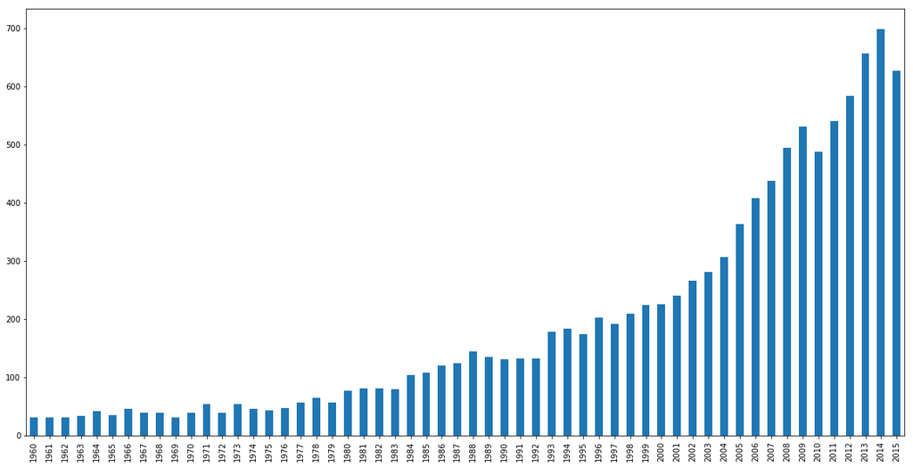

```python
movie_count_yr.plot(kind='bar', figsize = (20, 10))
```

The graph shows exponential growth in the count of movies from last 56 years, with maximum count in the year 2014

### Research Question 1 - Which genre movies are most popular each year?

### Splitting the genre values and stacking the columns

```python
## Splitting the genre values and stacking the columns
genres = genre_notnull.genres.str.split('|', expand = True).apply(pd.Series, 1).stack()
i = genres.index.get_level_values(0)
```

```python
## Creating dataframe with genre separated
genre_stacked = genre_notnull.loc[i].copy()
genre_stacked['genres'] = genres.values
genre_stacked.index = range(len(genre_stacked))
genre_stacked.head()
```

|  | id | imdb_id | popularity | budget | revenue | original_title | cast | homepage | director | tagline | ... | overview | runtime | genres | production_companies | release_date | vote_count | vote_average | release_year | budget_adj | revenue_adj |
| --- | --- | --- | --- | --- | --- | --- | --- | --- | --- | --- | --- | --- | --- | --- | --- | --- | --- | --- | --- | --- | --- |
| 0 | 135397 | tt0369610 | 32.985763 | 150000000 | 1513528810 | Jurassic World | Chris Pratt\|Bryce Dallas Howard\|Irrfan Khan\|Vi... | http://www.jurassicworld.com/ | Colin Trevorrow | The park is open. | ... | Twenty-two years after the events of Jurassic ... | 124 | Action | Universal Studios\|Amblin Entertainment\|Legenda... | 6/9/15 | 5562 | 6.5 | 2015 | 1.379999e+08 | 1.392446e+09 |
| 1 | 135397 | tt0369610 | 32.985763 | 150000000 | 1513528810 | Jurassic World | Chris Pratt\|Bryce Dallas Howard\|Irrfan Khan\|Vi... | http://www.jurassicworld.com/ | Colin Trevorrow | The park is open. | ... | Twenty-two years after the events of Jurassic ... | 124 | Adventure | Universal Studios\|Amblin Entertainment\|Legenda... | 6/9/15 | 5562 | 6.5 | 2015 | 1.379999e+08 | 1.392446e+09 |
| 2 | 135397 | tt0369610 | 32.985763 | 150000000 | 1513528810 | Jurassic World | Chris Pratt\|Bryce Dallas Howard\|Irrfan Khan\|Vi... | http://www.jurassicworld.com/ | Colin Trevorrow | The park is open. | ... | Twenty-two years after the events of Jurassic ... | 124 | Science Fiction | Universal Studios\|Amblin Entertainment\|Legenda... | 6/9/15 | 5562 | 6.5 | 2015 | 1.379999e+08 | 1.392446e+09 |
| 3 | 135397 | tt0369610 | 32.985763 | 150000000 | 1513528810 | Jurassic World | Chris Pratt\|Bryce Dallas Howard\|Irrfan Khan\|Vi... | http://www.jurassicworld.com/ | Colin Trevorrow | The park is open. | ... | Twenty-two years after the events of Jurassic ... | 124 | Thriller | Universal Studios\|Amblin Entertainment\|Legenda... | 6/9/15 | 5562 | 6.5 | 2015 | 1.379999e+08 | 1.392446e+09 |
| 4 | 76341 | tt1392190 | 28.419936 | 150000000 | 378436354 | Mad Max: Fury Road | Tom Hardy\|Charlize Theron\|Hugh Keays-Byrne\|Nic... | http://www.madmaxmovie.com/ | George Miller | What a Lovely Day. | ... | An apocalyptic story set in the furthest reach... | 120 | Action | Village Roadshow Pictures\|Kennedy Miller Produ... | 5/13/15 | 6185 | 7.1 | 2015 | 1.379999e+08 | 3.481613e+08 |

5 rows × 21 columns

### Finding the total count of movies for each genre

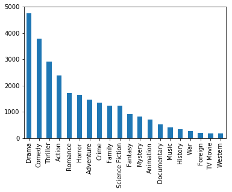

```python
genre_stacked.genres.value_counts()
genre_stacked.genres.value_counts().plot(kind = 'bar')
```

The graph shows that the maximum number of movies come into the category of genre 'Drama', followed by Comedy and then Thriller. And, the least count of movies are in category of 'TV Movies' and 'Western'

### Grouping the data by year and finding the most popular movie each year

```python
## Grouping the data by year and finding the maximum popular movies each year
idx = genre_stacked.groupby('release_year')['popularity'].transform(max) == genre_stacked['popularity']

popular_year = genre_stacked[idx]

## Genres of max popular movies each year
genre_year = popular_year[['release_year','genres', 'popularity']].sort_values('release_year')


genre_year
```

|  | release_year | genres | popularity |
| --- | --- | --- | --- |
| 25065 | 1960 | Drama | 2.610362 |
| 25066 | 1960 | Horror | 2.610362 |
| 25067 | 1960 | Thriller | 2.610362 |
| 24990 | 1961 | Adventure | 2.631987 |
| 24992 | 1961 | Comedy | 2.631987 |
| 24993 | 1961 | Family | 2.631987 |
| 24991 | 1961 | Animation | 2.631987 |
| 24302 | 1962 | Adventure | 3.170651 |
| 24304 | 1962 | Thriller | 3.170651 |
| 24303 | 1962 | Action | 3.170651 |
| 25839 | 1963 | Action | 2.508235 |
| 25840 | 1963 | Thriller | 2.508235 |
| 25841 | 1963 | Adventure | 2.508235 |
| 24386 | 1964 | Thriller | 3.153791 |
| 24385 | 1964 | Action | 3.153791 |
| 24384 | 1964 | Adventure | 3.153791 |
| 26493 | 1965 | Adventure | 1.910465 |
| 26494 | 1965 | Action | 1.910465 |
| 26495 | 1965 | Thriller | 1.910465 |
| 26843 | 1966 | Comedy | 1.227582 |
| 26841 | 1966 | Animation | 1.227582 |
| 26842 | 1966 | Family | 1.227582 |
| 25741 | 1967 | Family | 2.550704 |
| 25743 | 1967 | Adventure | 2.550704 |
| 25742 | 1967 | Animation | 2.550704 |
| 23970 | 1968 | Adventure | 3.309196 |
| 23968 | 1968 | Science Fiction | 3.309196 |
| 23969 | 1968 | Mystery | 3.309196 |
| 26587 | 1969 | Adventure | 1.778746 |
| 26588 | 1969 | Action | 1.778746 |
| ... | ... | ... | ... |
| 17835 | 2007 | Fantasy | 4.965391 |
| 6807 | 2008 | Action | 8.466668 |
| 6809 | 2008 | Thriller | 8.466668 |
| 6808 | 2008 | Crime | 8.466668 |
| 6806 | 2008 | Drama | 8.466668 |
| 3006 | 2009 | Science Fiction | 9.432768 |
| 3005 | 2009 | Fantasy | 9.432768 |
| 3003 | 2009 | Action | 9.432768 |
| 3004 | 2009 | Adventure | 9.432768 |
| 4364 | 2010 | Mystery | 9.363643 |
| 4365 | 2010 | Adventure | 9.363643 |
| 4362 | 2010 | Thriller | 9.363643 |
| 4363 | 2010 | Science Fiction | 9.363643 |
| 4361 | 2010 | Action | 9.363643 |
| 8045 | 2011 | Action | 8.411577 |
| 8046 | 2011 | Animation | 8.411577 |
| 8047 | 2011 | Horror | 8.411577 |
| 10567 | 2012 | Adventure | 7.637767 |
| 10565 | 2012 | Science Fiction | 7.637767 |
| 10566 | 2012 | Action | 7.637767 |
| 13104 | 2013 | Adventure | 6.112766 |
| 13103 | 2013 | Animation | 6.112766 |
| 13105 | 2013 | Family | 6.112766 |
| 1388 | 2014 | Science Fiction | 24.949134 |
| 1387 | 2014 | Drama | 24.949134 |
| 1386 | 2014 | Adventure | 24.949134 |
| 3 | 2015 | Thriller | 32.985763 |
| 2 | 2015 | Science Fiction | 32.985763 |
| 1 | 2015 | Adventure | 32.985763 |
| 0 | 2015 | Action | 32.985763 |

164 rows × 3 columns

```python
## Finding the genres that have maximum count in the most popularity movies from all years.
grouped_genre_year = genre_year.groupby('genres').count()

grouped_genre_year
```

| genres | release_year | popularity |
| --- | --- | --- |
| Action | 28 | 28 |
| Adventure | 30 | 30 |
| Animation | 9 | 9 |
| Comedy | 7 | 7 |
| Crime | 7 | 7 |
| Drama | 13 | 13 |
| Family | 11 | 11 |
| Fantasy | 10 | 10 |
| Horror | 4 | 4 |
| Music | 2 | 2 |
| Mystery | 3 | 3 |
| Romance | 2 | 2 |
| Science Fiction | 19 | 19 |
| Thriller | 19 | 19 |

### Heatmap Graph to show genres of most popular movie each year

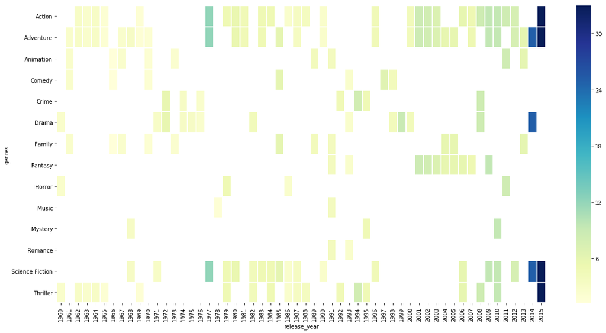

```python
data = genre_year.pivot(index='genres', columns='release_year', values='popularity')
fig, ax = plt.subplots(figsize=(20,10))
sns.heatmap(data, cmap="YlGnBu", ax = ax,  linewidths=1)
plt.show()
```

The above graph shows that - 1) Action, Adventure and Thriller movies have been most popular movies in most of the years 2) Romantic and Music movies have been most popular only twice. 3) Science Fiction has been the most popular movie genres for 19 years.

### Research Question 2) How the trend of genre has changed in the following years.

Grouping the data by 'release year' and 'genre' values and aggregating the size(count) of each genre in each year

```python
##Grouping the data by release year and genre values and aggregating the
##size(count) of each genre in each year
md2_year_genres = genre_stacked.groupby(['release_year', 'genres']).size().rename('genre_count').reset_index()

genre = md2_year_genres['genres'].unique()

data2= md2_year_genres.pivot(index='genres', columns='release_year', values='genre_count')

md2_year_genres
```

|  | release_year | genres | genre_count |
| --- | --- | --- | --- |
| 0 | 1960 | Action | 8 |
| 1 | 1960 | Adventure | 5 |
| 2 | 1960 | Comedy | 8 |
| 3 | 1960 | Crime | 2 |
| 4 | 1960 | Drama | 13 |
| 5 | 1960 | Family | 3 |
| 6 | 1960 | Fantasy | 2 |
| 7 | 1960 | Foreign | 1 |
| 8 | 1960 | History | 5 |
| 9 | 1960 | Horror | 7 |
| 10 | 1960 | Music | 1 |
| 11 | 1960 | Romance | 6 |
| 12 | 1960 | Science Fiction | 3 |
| 13 | 1960 | Thriller | 6 |
| 14 | 1960 | War | 2 |
| 15 | 1960 | Western | 6 |
| 16 | 1961 | Action | 7 |
| 17 | 1961 | Adventure | 6 |
| 18 | 1961 | Animation | 1 |
| 19 | 1961 | Comedy | 10 |
| 20 | 1961 | Crime | 2 |
| 21 | 1961 | Drama | 16 |
| 22 | 1961 | Family | 5 |
| 23 | 1961 | Fantasy | 2 |
| 24 | 1961 | Foreign | 1 |
| 25 | 1961 | History | 3 |
| 26 | 1961 | Horror | 3 |
| 27 | 1961 | Music | 2 |
| 28 | 1961 | Mystery | 1 |
| 29 | 1961 | Romance | 7 |
| ... | ... | ... | ... |
| 1019 | 2014 | Fantasy | 36 |
| 1020 | 2014 | History | 15 |
| 1021 | 2014 | Horror | 105 |
| 1022 | 2014 | Music | 28 |
| 1023 | 2014 | Mystery | 36 |
| 1024 | 2014 | Romance | 84 |
| 1025 | 2014 | Science Fiction | 62 |
| 1026 | 2014 | TV Movie | 14 |
| 1027 | 2014 | Thriller | 179 |
| 1028 | 2014 | War | 23 |
| 1029 | 2014 | Western | 6 |
| 1030 | 2015 | Action | 107 |
| 1031 | 2015 | Adventure | 69 |
| 1032 | 2015 | Animation | 39 |
| 1033 | 2015 | Comedy | 162 |
| 1034 | 2015 | Crime | 51 |
| 1035 | 2015 | Documentary | 57 |
| 1036 | 2015 | Drama | 260 |
| 1037 | 2015 | Family | 44 |
| 1038 | 2015 | Fantasy | 33 |
| 1039 | 2015 | History | 15 |
| 1040 | 2015 | Horror | 125 |
| 1041 | 2015 | Music | 33 |
| 1042 | 2015 | Mystery | 42 |
| 1043 | 2015 | Romance | 57 |
| 1044 | 2015 | Science Fiction | 86 |
| 1045 | 2015 | TV Movie | 20 |
| 1046 | 2015 | Thriller | 171 |
| 1047 | 2015 | War | 9 |
| 1048 | 2015 | Western | 6 |

1049 rows × 3 columns

### Heatmap graph to show the trend of genre each year.

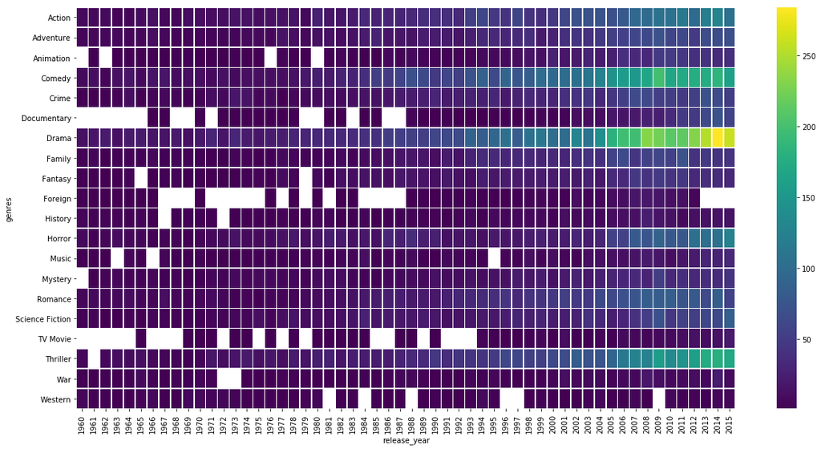

```python
fig, ax = plt.subplots(figsize=(20,10))
sns.heatmap(data2, fmt="g", cmap='viridis', linewidth = .5)
plt.show()
```

### Research Question 3) Does profit depend on popularity ?

Calculating the profit percentage for each movie considering the budget and revenue.

```python
#Profit percentage
md['profit%'] = (md['revenue'] - md['budget'])/md['budget']
md.columns
```

```
Index(['id', 'imdb_id', 'popularity', 'budget', 'revenue', 'original_title',
       'cast', 'homepage', 'director', 'tagline', 'keywords', 'overview',
       'runtime', 'genres', 'production_companies', 'release_date',
       'vote_count', 'vote_average', 'release_year', 'budget_adj',
       'revenue_adj', 'profit%'],
      dtype='object')
```

### Most popular movies each year

```python
## Most Popular movie each year
popular_movies_year = md.iloc[md.groupby('release_year')['popularity'].idxmax()]
popular_movies_year.head()
```

[output not shown]

### Revenue and Profit percentage distribution graph of most popular movie each year

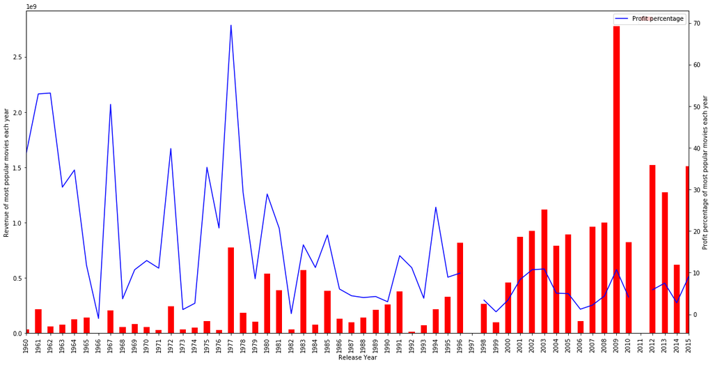

```python
ax = popular_movies_year.plot(x = 'release_year', y ='revenue', kind = 'bar', figsize = (20,10), color = 'r', label = 'Revenue')
ax2 = ax.twinx()
popular_movies_year.plot(ax.get_xticks(), y ='profit%',  ax = ax2, color = 'b', label = 'Profit percentage')

ax.set_ylabel('Revenue of most popular movies each year')
ax2.set_ylabel('Profit percentage of most popular movies each year')
ax.set_xlabel('Release Year')
```

### Least popular movies each year

```python
## Least Popular movie each year
least_popular_movie = md.loc[md.groupby('release_year')['popularity'].transform(min) == md['popularity']].sort_values('release_year')
least_popular_movie
```

|  | id | imdb_id | popularity | budget | revenue | original_title | cast | homepage | director | tagline | ... | runtime | genres | production_companies | release_date | vote_count | vote_average | release_year | budget_adj | revenue_adj | profit% |
| --- | --- | --- | --- | --- | --- | --- | --- | --- | --- | --- | --- | --- | --- | --- | --- | --- | --- | --- | --- | --- | --- |
| 10170 | 18973 | tt0053716 | 0.055821 | 3000000 | 7100000 | Cinderfella | Jerry Lewis\|Ed Wynn\|Judith Anderson\|Henry Silv... | NaN | Frank Tashlin | NaN | ... | 91 | Comedy\|Romance | Paramount Pictures\|Jerry Lewis Productions | 12/18/60 | 13 | 7.2 | 1960 | 2.211890e+07 | 5.234807e+07 | 1.366667 |
| 10140 | 29478 | tt0055353 | 0.027527 | 1500000 | 0 | A Raisin in the Sun | Sidney Poitier\|Claudia McNeil\|Ruby Dee\|Diana S... | NaN | Daniel Petrie | The Prize-Winning Drama that Warms the Screen ... | ... | 128 | Romance\|Drama | Columbia Pictures Corporation | 5/28/61 | 13 | 6.3 | 1961 | 1.094229e+07 | 0.000000e+00 | -1.000000 |
| 9880 | 12708 | tt0056575 | 0.038819 | 0 | 0 | That Touch of Mink | Cary Grant\|Doris Day\|Gig Young\|Audrey Meadows\|... | NaN | Delbert Mann | Two of Hollywood's most beloved stars, Cary Gr... | ... | 99 | Comedy\|Romance | Universal Pictures\|Arwin Productions | 6/14/62 | 16 | 5.6 | 1962 | 0.000000e+00 | 0.000000e+00 | NaN |
| 10471 | 27636 | tt0057078 | 0.045417 | 66500 | 0 | La frusta e il corpo | Daliah Lavi\|Christopher Lee\|Tony Kendall\|Ida G... | NaN | Mario Bava | The most deliriously romantic horror picture e... | ... | 87 | Mystery\|Horror | Titanus\|Leone Film | 8/29/63 | 11 | 6.7 | 1963 | 4.734919e+05 | 0.000000e+00 | -1.000000 |
| 9922 | 28177 | tt0058694 | 0.008990 | 65000 | 0 | Two Thousand Maniacs! | Connie Mason\|William Kerwin\|Jeffrey Allen\|Ben ... | NaN | Herschell Gordon Lewis | Madmen crazed for carnage! | ... | 87 | Horror | Friedman-Lewis Productions\|Jacqueline Kay | 3/20/64 | 13 | 6.5 | 1964 | 4.569674e+05 | 0.000000e+00 | -1.000000 |
| 10723 | 29067 | tt0059465 | 0.004770 | 0 | 0 | Die, Monster, Die! | Boris Karloff\|Nick Adams\|Freda Jackson\|Suzan F... | NaN | Daniel Haller | No one can stop this killing machine....It's A... | ... | 80 | Drama\|Horror\|Thriller\|Science Fiction\|Foreign | NaN | 10/26/65 | 10 | 6.4 | 1965 | 0.000000e+00 | 0.000000e+00 | NaN |
| 10847 | 28763 | tt0060548 | 0.034555 | 0 | 0 | Island of Terror | Peter Cushing\|Edward Judd\|Carole Gray\|Eddie By... | NaN | Terence Fisher | How could they stop the devouring death...that... | ... | 89 | Science Fiction\|Horror | Planet Film Productions\|Protelco | 6/20/66 | 13 | 5.3 | 1966 | 0.000000e+00 | 0.000000e+00 | NaN |
| 10437 | 24130 | tt0061810 | 0.034181 | 0 | 0 | In Like Flint | James Coburn\|Lee J. Cobb\|Jean Hale\|Andrew Dugg... | NaN | Gordon Douglas | FLINT'S BACK In Action... In Danger... In the ... | ... | 114 | Action\|Adventure\|Comedy | NaN | 3/15/67 | 13 | 5.5 | 1967 | 0.000000e+00 | 0.000000e+00 | NaN |
| 9757 | 44239 | tt0062653 | 0.005265 | 0 | 0 | The Alphabet | Peggy Lynch | NaN | David Lynch | NaN | ... | 4 | Animation | Pensylvania Academy of Fine Arts | 1/1/68 | 19 | 5.9 | 1968 | 0.000000e+00 | 0.000000e+00 | NaN |
| 10754 | 3171 | tt0064064 | 0.002757 | 0 | 0 | Bambi Meets Godzilla | NaN | NaN | Marv Newland | NaN | ... | 2 | Animation\|Comedy | NaN | 1/1/69 | 12 | 5.6 | 1969 | 0.000000e+00 | 0.000000e+00 | NaN |
| 10688 | 27172 | tt0066448 | 0.020760 | 0 | 0 | There Was a Crooked Man... | Kirk Douglas\|Henry Fonda\|Hume Cronyn\|Warren Oa... | NaN | Joseph L. Mankiewicz | NaN | ... | 126 | Action\|Comedy\|Drama\|Western | Warner Bros. | 9/18/70 | 10 | 6.7 | 1970 | 0.000000e+00 | 0.000000e+00 | NaN |
| 9977 | 32082 | tt0067217 | 0.000188 | 0 | 0 | The Hospital | George C. Scott\|Diana Rigg\|Richard Dysart\|Barn... | NaN | Arthur Hiller | Madness, Murder and Malpractice. | ... | 103 | Mystery\|Comedy\|Drama | Simcha Productions | 12/14/71 | 10 | 6.4 | 1971 | 0.000000e+00 | 0.000000e+00 | NaN |
| 7308 | 16993 | tt0068575 | 0.024345 | 0 | 0 | Fat City | Stacy Keach\|Jeff Bridges\|Susan Tyrrell\|Candy C... | NaN | John Huston | Life is what happens in between rounds. | ... | 100 | Drama | Columbia Pictures Corporation\|Rastar Pictures | 7/26/72 | 12 | 5.9 | 1972 | 0.000000e+00 | 0.000000e+00 | NaN |
| 10634 | 43003 | tt0072962 | 0.021941 | 0 | 0 | Vérités et Mensonges | Orson Welles\|Joseph Cotten\|Oja Kodar\|Elmyr de ... | NaN | Orson Welles | NaN | ... | 89 | Documentary | Janus Films\|SACI | 3/13/73 | 31 | 7.0 | 1973 | 0.000000e+00 | 0.000000e+00 | NaN |
| 9804 | 42449 | tt0071604 | 0.029670 | 0 | 30000 | Hearts and Minds | Georges Bidault\|Clark Clifford\|George Coker | NaN | Peter Davis | The Forever War. Goes On | ... | 112 | Documentary\|War | BBS Productions | 1/1/74 | 12 | 6.5 | 1974 | 0.000000e+00 | 1.326685e+05 | inf |
| 9844 | 32042 | tt0073453 | 0.017468 | 0 | 0 | Night Moves | Gene Hackman\|Jennifer Warren\|Susan Clark\|Harri... | NaN | Arthur Penn | Maybe he would find the girl... maybe he would... | ... | 100 | Mystery\|Thriller | Warner Bros.\|Layton Productions\|Hiller Product... | 6/11/75 | 18 | 6.1 | 1975 | 0.000000e+00 | 0.000000e+00 | NaN |
| 10219 | 48197 | tt0075342 | 0.002381 | 0 | 0 | The Town That Dreaded Sundown | Ben Johnson\|Andrew Prine\|Dawn Wells\|Jimmy Clem... | NaN | Charles B. Pierce | In 1946 this man killed five people... Today h... | ... | 86 | Horror\|Mystery\|Thriller\|Crime | American International Pictures (AIP) | 9/26/76 | 15 | 6.3 | 1976 | 0.000000e+00 | 0.000000e+00 | NaN |
| 1385 | 20785 | tt0075988 | 0.002457 | 0 | 0 | Emmet Otter's Jug-Band Christmas | NaN | NaN | Jim Henson | NaN | ... | 48 | Drama\|Comedy\|Family | NaN | 1/1/77 | 10 | 7.5 | 1977 | 0.000000e+00 | 0.000000e+00 | NaN |
| 10819 | 16214 | tt0077696 | 0.044675 | 0 | 78000000 | Hooper | Burt Reynolds\|Robert Klein\|Adam West\|Jan-Micha... | http://en.wikipedia.org/wiki/Hooper_(film) | Hal Needham | The greatest stuntman alive! | ... | 107 | Action\|Comedy | Warner Bros. | 7/28/78 | 13 | 6.0 | 1978 | 0.000000e+00 | 2.607307e+08 | inf |
| 7881 | 30547 | tt0078950 | 0.019263 | 0 | 0 | The Champ | Jon Voight\|Faye Dunaway\|Ricky Schroder\|Jack Wa... | NaN | Franco Zeffirelli | The most poignant love-triangle of all - a fat... | ... | 121 | Drama\|Family | Metro-Goldwyn-Mayer (MGM) | 7/10/79 | 12 | 7.1 | 1979 | 0.000000e+00 | 0.000000e+00 | NaN |
| 7386 | 30924 | tt0081184 | 0.031133 | 3000000 | 0 | Motel Hell | Rory Calhoun\|Paul Linke\|Nancy Parsons\|Nina Axe... | NaN | Kevin Connor | You might just die...laughing! | ... | 102 | Comedy\|Horror | Camp Hill | 8/14/80 | 24 | 5.9 | 1980 | 7.938110e+06 | 0.000000e+00 | -1.000000 |
| 8454 | 17205 | tt0082332 | 0.046679 | 0 | 0 | Enter the Ninja | Franco Nero\|Susan George\|Christopher George\|Sh... | NaN | Menahem Golan | Warriors of a lost martial art! Hired assassin... | ... | 100 | Crime\|Action\|Drama | City Film\|Golan-Globus Productions\|The Cannon ... | 7/17/81 | 11 | 5.5 | 1981 | 0.000000e+00 | 0.000000e+00 | NaN |
| 8968 | 32336 | tt0084873 | 0.003659 | 0 | 0 | Vokzal dlya Dvoikh | Lyudmila Gurchenko\|Nikita Mikhalkov\|Oleg Basil... | NaN | Eldar Ryazanov | NaN | ... | 141 | Drama\|Romance\|Comedy | Mosfilm | 6/6/82 | 10 | 6.0 | 1982 | 0.000000e+00 | 0.000000e+00 | NaN |
| 8053 | 37777 | tt0086850 | 0.002120 | 0 | 0 | Acqua e sapone | Carlo Verdone\|Natasha Hovey\|Glenn Saxson\|Elena... | NaN | Carlo Verdone | NaN | ... | 109 | Drama\|Family | NaN | 10/27/83 | 21 | 6.1 | 1983 | 0.000000e+00 | 0.000000e+00 | NaN |
| 7976 | 27171 | tt0087635 | 0.059713 | 0 | 0 | The Lonely Guy | Steve Martin\|Charles Grodin\|Merv Griffin\|Judit... | NaN | Arthur Hiller | NaN | ... | 90 | Comedy\|Romance | Universal Pictures\|Aspen Film Society | 1/27/84 | 13 | 6.2 | 1984 | 0.000000e+00 | 0.000000e+00 | NaN |
| 6181 | 18729 | tt0088583 | 0.000065 | 0 | 0 | North and South, Book I | Patrick Swayze\|Philip Casnoff\|Kirstie Alley\|Ge... | NaN | NaN | NaN | ... | 561 | Drama\|History\|Western | NaN | 11/3/85 | 17 | 6.0 | 1985 | 0.000000e+00 | 0.000000e+00 | NaN |
| 10592 | 38343 | tt0092276 | 0.001567 | 0 | 0 | Yuppies 2 | Massimo Boldi\|Jerry CalÃ \|Christian De Sica\|Ez... | NaN | Enrico Oldoini | NaN | ... | 104 | Comedy | NaN | 1/1/86 | 11 | 5.0 | 1986 | 0.000000e+00 | 0.000000e+00 | NaN |
| 9708 | 59558 | tt0092549 | 0.005529 | 0 | 0 | Miami Connection | Y.K. Kim\|Vincent Hirsch\|Joseph Diamand\|Maurice... | http://drafthousefilms.com/film/miami-connection | Y.K. Kim\|Woo-sang Park | Greetings from the most dangerous jungle in th... | ... | 86 | Action\|Crime | Drafthouse Films | 8/18/87 | 13 | 5.8 | 1987 | 0.000000e+00 | 0.000000e+00 | NaN |
| 9593 | 46188 | tt0220698 | 0.001662 | 0 | 0 | Peter Pan | NaN | NaN | NaN | NaN | ... | 52 | Action\|Adventure\|Animation\|Family\|Fantasy | Burbank Films Australia | 1/1/88 | 28 | 6.6 | 1988 | 0.000000e+00 | 0.000000e+00 | NaN |
| 9312 | 52106 | tt0178579 | 0.010016 | 0 | 0 | Ho vinto la lotteria di Capodanno | Paolo Villaggio\|Antonio Allocca\|Camillo Milli\|... | NaN | Neri Parenti | NaN | ... | 92 | Comedy | NaN | 6/6/89 | 13 | 6.0 | 1989 | 0.000000e+00 | 0.000000e+00 | NaN |
| 10109 | 31597 | tt0100224 | 0.024987 | 0 | 0 | Narrow Margin | Gene Hackman\|Anne Archer\|James Sikking\|J. T. W... | NaN | Peter Hyams | It will take you to the edge of suspense. | ... | 97 | Action\|Thriller\|Crime\|Mystery | Universal Pictures\|TriStar Pictures\|Carolco Pi... | 9/21/90 | 11 | 5.4 | 1990 | 0.000000e+00 | 0.000000e+00 | NaN |
| 9448 | 31544 | tt0102045 | 0.048237 | 0 | 4654288 | The Hitman | Chuck Norris\|Alberta Watson\|Michael Parks\|Al W... | NaN | Aaron Norris | He's so far undercover he may never get back. | ... | 95 | Action\|Crime\|Thriller | Twilight Motion Picture Seven Ltd. Partnership... | 5/1/91 | 11 | 5.2 | 1991 | 0.000000e+00 | 7.451947e+06 | inf |
| 8374 | 33380 | tt0274518 | 0.006863 | 0 | 0 | Gayniggers from Outer Space | Gbatokai Dakinah | NaN | Morten Lindberg | NaN | ... | 26 | Comedy\|Science Fiction | NaN | 1/1/92 | 11 | 4.0 | 1992 | 0.000000e+00 | 0.000000e+00 | NaN |
| 10397 | 25117 | tt0152183 | 0.012941 | 0 | 0 | Bill Hicks: Revelations | Bill Hicks | NaN | Chris Bould | NaN | ... | 60 | Comedy | NaN | 5/27/93 | 11 | 7.8 | 1993 | 0.000000e+00 | 0.000000e+00 | NaN |
| 4345 | 35977 | tt0110913 | 0.061916 | 0 | 0 | Pumpkinhead II: Blood Wings | Andrew Robinson\|Ami Dolenz\|Soleil Moon Frye\|J.... | NaN | Jeff Burr | They couldn't leave dead enough alone. | ... | 88 | Horror | Live Entertainment\|Motion Picture Corporation ... | 3/16/94 | 17 | 5.1 | 1994 | 0.000000e+00 | 0.000000e+00 | NaN |
| 8240 | 32458 | tt0116344 | 0.013131 | 0 | 0 | Forgotten Silver | Peter Jackson\|Johnny Morris\|Costa Botes\|Harvey... | NaN | Costa Botes\|Peter Jackson | NaN | ... | 53 | Comedy\|Documentary\|Foreign | NaN | 10/28/95 | 15 | 5.4 | 1995 | 0.000000e+00 | 0.000000e+00 | NaN |
| 8660 | 28121 | tt0117891 | 0.028143 | 0 | 0 | A Thin Line Between Love and Hate | Lynn Whitfield\|Martin Lawrence\|Regina King\|Del... | NaN | Martin Lawrence | When you play, you pay. | ... | 108 | Comedy\|Thriller\|Crime\|Romance | New Line Cinema\|Savoy Pictures | 4/4/96 | 10 | 6.3 | 1996 | 0.000000e+00 | 0.000000e+00 | NaN |
| 5420 | 37410 | tt0122529 | 0.022145 | 0 | 1334786 | Henry Fool | Thomas Jay Ryan\|James Urbaniak\|Parker Posey\|Ma... | NaN | Hal Hartley | NaN | ... | 137 | Comedy\|Drama | Shooting Gallery\|True Fiction Pictures | 9/7/97 | 14 | 6.9 | 1997 | 0.000000e+00 | 1.813254e+06 | inf |
| 9178 | 51216 | tt0190419 | 0.029699 | 0 | 0 | Ghulam | Aamir Khan\|Rani Mukerji\|Rajit Kapoor\|Deepak Ti... | NaN | Vikram Bhatt | NaN | ... | 162 | Crime\|Drama\|Romance\|Foreign | NaN | 6/19/98 | 10 | 5.0 | 1998 | 0.000000e+00 | 0.000000e+00 | NaN |
| 2632 | 31524 | tt0200087 | 0.015074 | 0 | 0 | Sarfarosh | Naseeruddin Shah\|Aamir Khan\|Sonali Bendre\|Muke... | NaN | John Mathew Matthan | NaN | ... | 162 | Foreign | NaN | 4/30/99 | 12 | 7.0 | 1999 | 0.000000e+00 | 0.000000e+00 | NaN |
| 8887 | 44756 | tt0250440 | 0.004010 | 0 | 0 | Is It Fall Yet? | Tracy Grandstaff\|Wendy Hoopes | NaN | Karen Disher\|Guy Moore | NaN | ... | 75 | Animation\|Comedy | NaN | 8/27/00 | 14 | 7.3 | 2000 | 0.000000e+00 | 0.000000e+00 | NaN |
| 2874 | 57961 | tt0286975 | 0.001349 | 165000 | 0 | Slashers | Tony Curtis Blondell | NaN | Maurice Devereaux | Are you Game? | ... | 99 | Comedy\|Horror\|Fantasy | NaN | 1/1/01 | 11 | 5.5 | 2001 | 2.031955e+05 | 0.000000e+00 | -1.000000 |
| 4170 | 24232 | tt0285627 | 0.009266 | 0 | 0 | Is It College Yet? | Tracy Grandstaff\|Wendy Hoopes | NaN | Karen Disher | NaN | ... | 90 | Animation\|Comedy | NaN | 1/1/02 | 14 | 7.2 | 2002 | 0.000000e+00 | 0.000000e+00 | NaN |
| 5228 | 24362 | tt0368575 | 0.013546 | 0 | 0 | The Second Renaissance Part II | Julia Fletcher\|Dane A. Davis\|Debi Derryberry\|J... | NaN | Mahiro Maeda | NaN | ... | 9 | Science Fiction\|Animation | Studio 4°C | 6/1/03 | 15 | 7.2 | 2003 | 0.000000e+00 | 0.000000e+00 | NaN |
| 7268 | 1392 | tt0388789 | 0.001117 | 350000 | 3515061 | Born into Brothels | Zana Briski\|Avijit\|Geeta Masi\|Kochi\|Mamuni | http://www.kids-with-cameras.org/bornintobroth... | Zana Briski\|Ross Kauffman | NaN | ... | 85 | Documentary | NaN | 12/8/04 | 23 | 6.4 | 2004 | 4.040559e+05 | 4.057946e+06 | 9.043031 |
| 6551 | 31329 | tt0445570 | 0.000973 | 0 | 0 | Mon petit doigt m'a dit... | Catherine Frot\|André Dussollier\|Geneviève Bu... | NaN | Pascal Thomas | NaN | ... | 105 | Comedy\|Mystery | Rhône-Alpes Cinéma\|France2 Cinéma | 4/13/05 | 13 | 5.7 | 2005 | 0.000000e+00 | 0.000000e+00 | NaN |
| 6961 | 15412 | tt0466460 | 0.001115 | 0 | 0 | Khosla Ka Ghosla! | Anupam Kher\|Boman Irani\|Parvin Dabas\|Tara Shar... | NaN | Dibakar Banerjee | A Delhi-based retired middle class man tries t... | ... | 135 | Comedy | UTV Motion Pictures | 9/22/06 | 10 | 6.8 | 2006 | 0.000000e+00 | 0.000000e+00 | NaN |
| 7781 | 13120 | tt0989000 | 0.004196 | 25000 | 0 | In Search of a Midnight Kiss | Scoot McNairy\|Sara Simmonds\|Brian McGuire | NaN | Alex Holdridge | NaN | ... | 90 | Comedy\|Drama\|Romance | NaN | 4/27/07 | 14 | 5.5 | 2007 | 2.629171e+04 | 0.000000e+00 | -1.000000 |
| 3370 | 15953 | tt1020955 | 0.001317 | 0 | 0 | Fuera de carta | Javier Cámara\|Lola Dueñas\|Fernando Tejero\|Be... | http://www.fueradecarta.com | Nacho G. Velilla | NaN | ... | 111 | Comedy | TLA Releasing | 4/11/08 | 13 | 5.3 | 2008 | 0.000000e+00 | 0.000000e+00 | NaN |
| 1918 | 31687 | tt1520496 | 0.001423 | 0 | 0 | Circle of Eight | Austin Highsmith\|Jesse Johnson\|Ryan Doom\|Josh ... | NaN | Stephen Cragg | NaN | ... | 84 | Mystery\|Horror | Bronson Avenue\|Paramount Pictures Digital Ente... | 10/27/09 | 11 | 4.3 | 2009 | 0.000000e+00 | 0.000000e+00 | NaN |
| 2408 | 40025 | tt1572168 | 0.004433 | 0 | 0 | æ’•ç¥¨é¢¨é›² | Fala Chen\|Simon Yam\|Andy On\|Michael Miu Kiu-Wa... | NaN | Venus Keung Kwok-Man\|Wong Jing | NaN | ... | 93 | Action\|Thriller | NaN | 1/7/10 | 12 | 6.4 | 2010 | 0.000000e+00 | 0.000000e+00 | NaN |
| 3910 | 79976 | tt2096615 | 0.002006 | 0 | 0 | Steve Jobs: One Last Thing | NaN | NaN | NaN | NaN | ... | 60 | Documentary | NaN | 11/2/11 | 11 | 6.6 | 2011 | 0.000000e+00 | 0.000000e+00 | NaN |
| 4948 | 84288 | tt2120152 | 0.001372 | 0 | 0 | The Invisible War | Kori Cioca\|Jessica Hinves\|Ariana Klay\|Elle Hel... | http://invisiblewarmovie.com/ | Kirby Dick | The Battleground Is Your Barracks | ... | 93 | Crime\|Drama\|History\|Documentary | Canal+\|Chain Camera Pictures\|ITVS\|Rise Films\|G... | 1/20/12 | 17 | 7.0 | 2012 | 0.000000e+00 | 0.000000e+00 | NaN |
| 6080 | 174323 | tt2429074 | 0.000620 | 0 | 0 | G.B.F. | Michael J. Willett\|Paul Iacono\|Sasha Pieterse\|... | https://www.facebook.com/GBFmovie | Darren Stein | Being out has never been so in. | ... | 92 | Comedy | School Pictures\|Parting Shots Media\|Logolite E... | 10/20/13 | 82 | 6.1 | 2013 | 0.000000e+00 | 0.000000e+00 | NaN |
| 1328 | 288301 | tt3997238 | 0.002599 | 0 | 0 | Do I Sound Gay? | Michael Airington\|Margaret Cho\|Tim Gunn\|Jeff H... | http://www.doisoundgay.com | David Thorpe | NaN | ... | 77 | Documentary | NaN | 7/10/14 | 12 | 5.8 | 2014 | 0.000000e+00 | 0.000000e+00 | NaN |
| 628 | 333346 | tt4323536 | 0.003920 | 0 | 0 | The Emperor's New Clothes | Russell Brand | NaN | Michael Winterbottom | NaN | ... | 107 | Documentary | NaN | 4/24/15 | 11 | 6.1 | 2015 | 0.000000e+00 | 0.000000e+00 | NaN |

56 rows × 22 columns

### Revenue and Profit percentage distribution graph of least popular movie each year¶

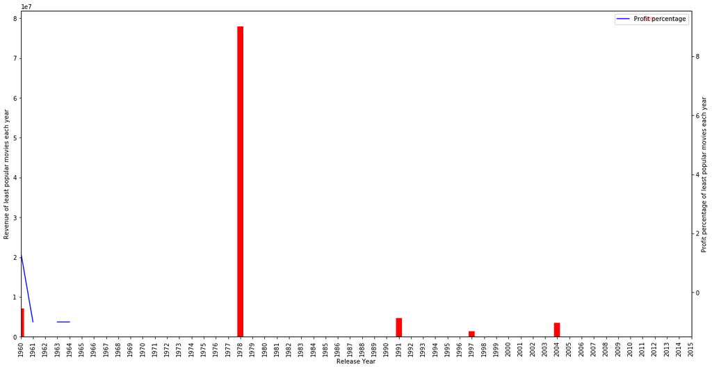

```python
ax = least_popular_movie.plot(x = 'release_year', y ='revenue', kind = 'bar', figsize = (20,10), color = 'r', label = 'Revenue')
ax2 = ax.twinx()
least_popular_movie.plot(ax.get_xticks(), y ='profit%',  ax = ax2, color = 'b', label = 'Profit percentage')

ax.set_ylabel('Revenue of least popular movies each year')
ax2.set_ylabel('Profit percentage of least popular movies each year')
ax.set_xlabel('Release Year')
```

Above graph shows zero profit and zero revenue for most of the least popular movies. Possible that the data is incorrect or the missing values have been replaced with zero value.

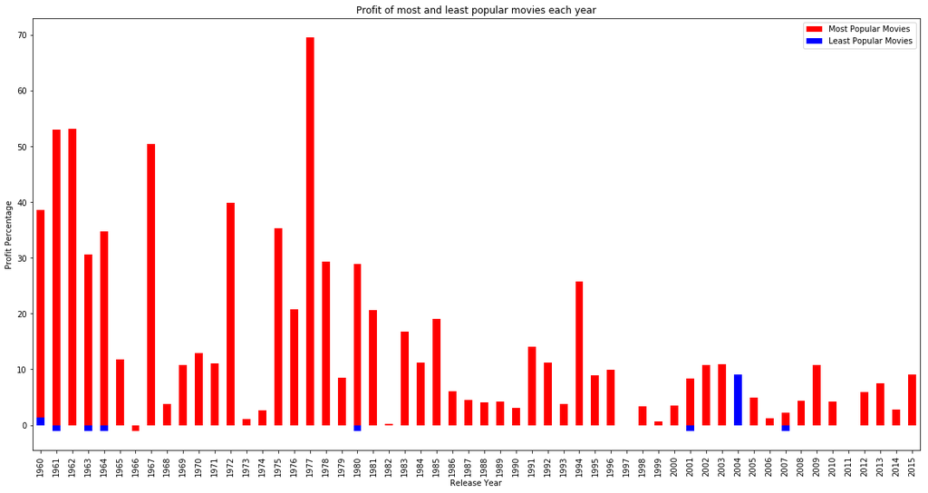

```python
ax = popular_movies_year.plot.bar(x = 'release_year', y ='profit%', figsize=(20,10), color = 'red', label = 'Most Popular Movies')
least_popular_movie.plot.bar(x = 'release_year', y ='profit%', color = 'blue', ax = ax, label = 'Least Popular Movies')


plt.ylabel('Profit Percentage')
plt.xlabel('Release Year')
plt.title('Profit of most and least popular movies each year')

plt.legend()
plt.show()
```

From above graph it can be noticed that there has been very less or no profit for least popular movies. In some year, the movies has also been in loss.

```python
least_popular_movie[['release_year','budget','revenue']]
```

|  | release_year | budget | revenue |
| --- | --- | --- | --- |
| 10170 | 1960 | 3000000 | 7100000 |
| 10140 | 1961 | 1500000 | 0 |
| 9880 | 1962 | 0 | 0 |
| 10471 | 1963 | 66500 | 0 |
| 9922 | 1964 | 65000 | 0 |
| 10723 | 1965 | 0 | 0 |
| 10847 | 1966 | 0 | 0 |
| 10437 | 1967 | 0 | 0 |
| 9757 | 1968 | 0 | 0 |
| 10754 | 1969 | 0 | 0 |
| 10688 | 1970 | 0 | 0 |
| 9977 | 1971 | 0 | 0 |
| 7308 | 1972 | 0 | 0 |
| 10634 | 1973 | 0 | 0 |
| 9804 | 1974 | 0 | 30000 |
| 9844 | 1975 | 0 | 0 |
| 10219 | 1976 | 0 | 0 |
| 1385 | 1977 | 0 | 0 |
| 10819 | 1978 | 0 | 78000000 |
| 7881 | 1979 | 0 | 0 |
| 7386 | 1980 | 3000000 | 0 |
| 8454 | 1981 | 0 | 0 |
| 8968 | 1982 | 0 | 0 |
| 8053 | 1983 | 0 | 0 |
| 7976 | 1984 | 0 | 0 |
| 6181 | 1985 | 0 | 0 |
| 10592 | 1986 | 0 | 0 |
| 9708 | 1987 | 0 | 0 |
| 9593 | 1988 | 0 | 0 |
| 9312 | 1989 | 0 | 0 |
| 10109 | 1990 | 0 | 0 |
| 9448 | 1991 | 0 | 4654288 |
| 8374 | 1992 | 0 | 0 |
| 10397 | 1993 | 0 | 0 |
| 4345 | 1994 | 0 | 0 |
| 8240 | 1995 | 0 | 0 |
| 8660 | 1996 | 0 | 0 |
| 5420 | 1997 | 0 | 1334786 |
| 9178 | 1998 | 0 | 0 |
| 2632 | 1999 | 0 | 0 |
| 8887 | 2000 | 0 | 0 |
| 2874 | 2001 | 165000 | 0 |
| 4170 | 2002 | 0 | 0 |
| 5228 | 2003 | 0 | 0 |
| 7268 | 2004 | 350000 | 3515061 |
| 6551 | 2005 | 0 | 0 |
| 6961 | 2006 | 0 | 0 |
| 7781 | 2007 | 25000 | 0 |
| 3370 | 2008 | 0 | 0 |
| 1918 | 2009 | 0 | 0 |
| 2408 | 2010 | 0 | 0 |
| 3910 | 2011 | 0 | 0 |
| 4948 | 2012 | 0 | 0 |
| 6080 | 2013 | 0 | 0 |
| 1328 | 2014 | 0 | 0 |
| 628 | 2015 | 0 | 0 |

On further analysis, it is found that most of the least popular movies show zero value revenue and budget. This shows that the data has some problem. There are chances that the missing values have been replaced with the zero value.